## Project: American Community Surveys (2013 and 2014)

### Project Description

Term: Fall 2016

- Team 11
- Project title: Inequity distribution in US society
- Team members:
  - Cen Zeng
  - Jaime Gacitua
  - Ying Zhu
  - Yixin Sun
- Project summary: We want to display that there exist inequity income and unemployment rate which can be serious problems influencing our life. Some of inequity we can improve by ourself, but some we can not. We wish government can improve policy to reduce this inequity.

## Research Question:

Is there any inequity in society? If there is, how those unbalance influence our life ? More specifically: 1. Which state can get better life? Which degree of education has high income or low unemployment rate? Which occupation is the best one who should consider? 2. Is there any unfairness between male and female?

## Introduction:

Most of us are the last semester of graduated students here. We are going to find the job as soon. So we want to build a model to figure out inequity in society. We display it from two part: income and unemployment rate. Firstly, we use 2014 ACS 1-year personal data to construct multiple graphs to show the distribution of income according to several factors. Then we build a model to display the unemployment rate’s distribution in US. During these two steps, we choose several factors to carry out different survey in different aspects. In the end, we find out that unfairness do exist in both income and unemployment rate and we suggest that some appropriate changes in state policy might ameliorate this situation.

## Preprocess data

We search from dictionary and choose variables below to set up our model. Data is chosen from 2014 ACS 1-year personal-level.

| Variables | Dictionary |
| --- | --- |
| 1.SERIALNO | Unique code for person |
| 2.ST | State Code |
| 3.SEX | Gender |
| 4.AGEP | Age |
| 5.SCHL | Educational Attainment |
| 6.FOD1P | Field of Degree - First Entry |
| 7.FOD1P | Field of Degree - Second Entry |
| 8.WKHP | Hours Worked per Week |
| 9.WAGP | Wages or salary income |
| 10.ESR | Employment Status Recode |
| 11.PINCP | Total Person’s Income |
| 12.PERNP | Total Person’s Earning |
| 13.JWMNP | Travel time to work |

Here we have to read the dictionary carefully since there are NAs in the columns which actually have means. The meanings in the NA in different variables:

| Variables | NA meanings |
| --- | --- |
| SERIALNO | No NA |
| ST | No NA |
| SEX | No NA |
| AGEP | No NA |
| SCHL | Less than 3 years old |
| FOD1P | Less than bachelor’s degree |
| FOD1P | Less than bachelor’s degree |
| WKHP | Less than 16 years old/did not work |
| WAGP | Less than 15 years old |
| ESR | Less than 16 years old |
| PINCP | Less than 15 years old |
| PERNP | Less than 15 years old |
| JWMNP | not a worker or worker who worked at home |

# Visualization:

## 1.Income status in US

### 1.1 Gender, Age and Income

```r
plot_ly(data = final, x = Age, y = Income, mode = "markers",
        color = final[,1], size = final[,2], title="a")%>%
  layout(title = '2014 US averge personal income by Gender and Age')
```

[interactive chart not shown]

Inequity of income exists in gender. As we can see in the plot, the average income of male is always higher than female’s. Also, people’s income tend to achieve the peak around 45, where male and female’s income difference is also maximized.

### 1.2 Education, Working Hours and Income

```r
plot_ly(z=INCOME,type="surface",colorbar = list(title = "USD"))%>%
  layout(title = '2014 US averge personal income by Education and Working Hours',
         xaxis = list(title='EDU'))
```

[interactive chart not shown]

From this 3D plot, where x stands for Education level and y stands for average working hours per week, we can clearly see that people’s income will increase along with both education level and working duration per week. So, study harder, work harder and earn more!

### 1.3 Occupation and income

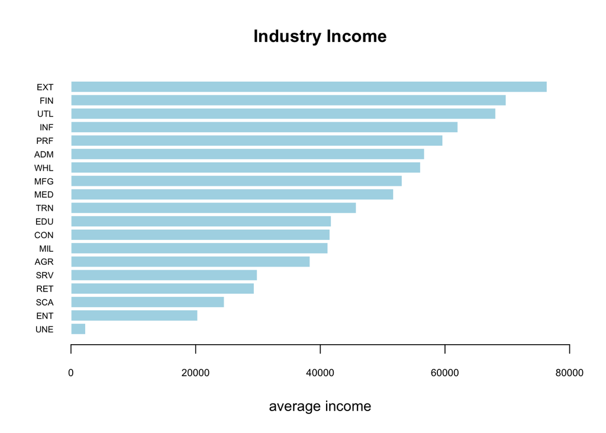

```r
barplot(sort(INDincome), horiz=T,col = "light blue",xlab = "average income",
        main = "Industry Income", border=F,xlim=c(0,80000),
        cex.axis=0.7,names.arg = unique(ind_code[,3])[order(INDincome)],
        cex.names=0.6,las=1)
```

Ext: OIL AND GAS EXTRACTION Fin: Finance Ent: RESTAURANTS AND OTHER FOOD SERVICES SCA: INDIVIDUAL AND FAMILY SERVICES

As we can see from the bar-plot, people working in Oil And Gas Extraction industry and Finance industry tend to achieve the highest income. On the other hand, income of Food Service industry performs pretty bad. The government may introduce some policies to promote the development of low income groups. Otherwise more and more people may want to quit these occupations.

### 1.4 States and income

```r
plot_ly(map1, z = map1[,3], locations = code, type = 'choropleth',
        locationmode = 'USA-states', color = map1[,3], colors = 'Greens',
        marker = list(line = l), colorbar = list(title = "USD"))%>%
  layout(title = '2014 US averge personal income by State', geo = g)
```

[interactive chart not shown]

This is non-weighted income distribution map. From the map, people work in New York and California seem to have impressive income. Since different states have different cost of living levels, we took 2014 RPP (Regional Price Parities) in to consideration. The following maps are associated with RPP and Adjusted Income.

#### 1.4.1 RPP map

```r
plot_ly(map1.7, z = map1.7[,3], locations = code, type = 'choropleth',
        locationmode = 'USA-states', color = map1.7[,3], colors = 'Blues',
        marker = list(line = l), colorbar = list(title = "Index"))%>%
  layout(title = '2014 US RPP by State', geo = g)
```

[interactive chart not shown]

New York and California have high cost of living as well.

#### 1.4.2 Adjusted Income Map

```r
plot_ly(map1.71, z = map1.71[,3], locations = code, type = 'choropleth',
        locationmode = 'USA-states', color = map1.71[,3], colors = 'Oranges',
        marker = list(line = l), colorbar = list(title = "UDS"))%>%
  layout(title = '2014 US adjusted income by State', geo = g)
```

[interactive chart not shown]

More fairly, we choose purchase power(adjusted income) here to show the wealth of each state. As we can see, high income does not imply high quality of life. People in New York (NY) and California (CA) can earn a lot of money but also spend a lot. In the end, states like North Dakota(ND) and Colorado(CO) may perform much better on people’s adjusted income than New York.

## 2.Employment status in US

Unemployment rate is defined basically by the percentage of the total labor force that is unemployed but actively seeking employment and willing to work. That is. Unemployment rate = Unemployed / Total labor force.

### 2.1 Description of Unemployment status

```r
us_emp<-nrow(as.matrix(Proj_1[which(ESR==1|ESR==2|ESR==4|ESR==5)]))
us_unemp<-nrow(as.matrix(Proj_1[which(ESR==3)]))
us_rate<- us_unemp/(us_emp+us_unemp)
us_rate
```

```
## [1] 0.06727637
```

### 2.2 Female and Male’s Unemployment rate

```r
male_emp<-nrow(as.matrix(Proj_1[which(SEX==1&
                                       (ESR==1|ESR==2|ESR==4|ESR==5))]))
male_unemp<-nrow(as.matrix(Proj_1[which(ESR==3&SEX==1)]))
female_emp<-nrow(as.matrix(Proj_1[which(SEX==2&
                                       (ESR==1|ESR==2|ESR==4|ESR==5))]))
female_unemp<-nrow(as.matrix(Proj_1[which(ESR==3&SEX==2)]))
male_rate<- male_unemp/(male_emp+male_unemp)
female_rate<- female_unemp/(female_emp+female_unemp)
male_rate
```

```
## [1] 0.06833642
```

```r
female_rate
```

```
## [1] 0.0661214
```

### 2.3 Gender, Education and Unemployment Rate

```r
figure(width = NULL, height = NULL) %>%
ly_points( unemployment.rate,education.attainment,data = edu_gender,
    color = filter, glyph = filter,
    hover = list( unemployment.rate,education.attainment))
```

[interactive chart not shown]

```r
gather(edu_gender_sub, Sex, value, s_Women, s_Men) %>%
  plot_ly(x = value, y = edu_atm, mode = "markers",
          color = Sex, colors = c("pink", "blue")) %>%
  add_trace(x = value, y = edu_atm, mode = "lines",
            group = edu_atm, showlegend = F, line = list(color = "gray")) %>%
  layout(
    title = "Gender earnings disparity",
    xaxis = list(title = "Annual Salary (in thousands)"),
    margin = list(l = 65)
  )
```

[interactive chart not shown]

### 2.4 States and Unemployment Rate

```r
plot_ly(map1, z = map1[,3], locations = code, type = 'choropleth',
        locationmode = 'USA-states', color = map1[,3], colors = 'Greens',
        marker = list(line = l), colorbar = list(title = "Unemp_ratae"))%>%
  layout(title = '2014 US unemployment rate by State', geo = g)
```

[interactive chart not shown]

ND (North Dakota) gives us a surprise here. This place has both high purchasing power according to previous income research and low unemployment rate. We have to say that people living there are lucky. Also moving to North Dakota might be a good idea. Overall, central area of US might be a better place to live in.

### 2.5 Education degree and Employment status

```r
sankeyNetwork(Links = netfile, Nodes = nodes, Source = "source",
Target = "target", Value = "value", NodeID = "name",
units = "TWh", fontSize = 12, nodeWidth = 30)
```

[interactive chart not shown]

For you to enjoy our project, we try to build a beautiful graph to display unemployment rate in education. High school seems to be a bad deal with its highest unemployment rate. Another thing we should notice is the large percentage of “not in labor force”. It may reflect population aging situation to some degree.

## Conclusion:

Generally, inequity exists in society which influence our life a lot. As you can see in our project. If you want to have a better life, you have to consider a series of problems. Like changing your gender if you do not have a great degree (just a joke). Or maybe you can choose middle states in US to live in. Or consider job associate with finance.On the government side, some policies changes like adjustment of tax and subsidy should also be helpful.

[interactive chart not shown]

Thank you for your time. We build this lovely graph in the end to make you have a little bit fun. You can drag it as you like.